# A4

## A4 EDA

We are measuring the effects of changing International Currency Rates on United States unemployment rates to see if there is any correlation between the two.

### Data Prep

Our data preparation involved both web scraping and cleaning up the data that we used. As a team, we web scraped off of the website to obtain the currency exchange data for the last ten years (python code in github repo) for the countries we had selected (the currency rates were in terms of US dollars). After that we used tools such as excel to build a master file that contained data from all of the countries and their currency exchange rates per month per year for the last ten years. We also managed to get a dataset online that had unemployment rates for the last ten years to compare it to. We decided to divide up the EDA work by country, the countries I will be focusing on in this EDA are India and Canada.

```r
country_df <- read.csv(file="data.csv",head=TRUE,sep=",") #master file for all countries
unemp_df <- read.csv(file = "unemployment.csv", head = TRUE, sep = ",") # US Unemployment rate data
india_df <- read.csv(file = "indianrupee.csv", head = TRUE, sep = ",")
canada_df <- read.csv(file = "canadiandollar.csv", head = TRUE, sep = ",")
```

### Describing data structure

Here are the dimensions of all the data structures being analyzed:

```r
#country master data
dim(country_df)
```

```
## [1] 120   9
```

```r
#unemployment data
dim(unemp_df)
```

```
## [1] 10 13
```

```r
#Currency Rate data specific to India
dim(india_df)
```

```
## [1] 10 13
```

```r
#Currency Rate data specific to Canada
dim(canada_df)
```

```
## [1] 10 13
```

```r
names(country_df)
```

```
## [1] "X"              "India"          "Japan"          "China"
## [5] "Korea"          "Canada"         "Brazil"         "Russia"
## [9] "European.Union"
```

The data is continuous. We are measuring the change over time and if trends are correlated for two datasets to see if they possibly influence each other or are related in any way. For the country data, the values are measurements of average currency exchange rates per month for the last ten years (measured by US dollar base). For the unemployment data, the values are the unemployment rates during each month of the last ten years. Data from both data sets is continuous and we will be measuring changes through time for both.

### Univariate analysis

Here are some of the summary stats and examples of the data points to get more sense of the data:

```r
#for the overall country data
str(country_df)
```

```
## 'data.frame':    120 obs. of  9 variables:
##  $ X             : Factor w/ 120 levels "Apr-07","Apr-08",..: 41 31 71 1 81 61 51 11 111 101 ...
##  $ India         : num  44.3 44.2 44 42.2 40.8 ...
##  $ Japan         : num  121 120 117 119 121 ...
##  $ China         : num  7.79 7.75 7.74 7.72 7.67 ...
##  $ Korea         : num  936 937 943 931 928 ...
##  $ Canada        : num  1.18 1.17 1.17 1.13 1.09 ...
##  $ Brazil        : num  2.14 2.09 2.09 2.03 2.03 ...
##  $ Russia        : num  26.5 26.3 26.1 25.8 25.8 ...
##  $ European.Union: num  1.3 1.31 1.32 1.35 1.35 ...
```

```r
head(country_df, n = 5)
```

```
##        X    India    Japan    China    Korea   Canada   Brazil   Russia
## 1 Jan-07 44.33947 120.5784 7.789589 936.3591 1.175932 2.138282 26.53018
## 2 Feb-07 44.16235 120.4463 7.754627 937.3625 1.170660 2.094159 26.32222
## 3 Mar-07 44.02550 117.2757 7.738982 943.2571 1.166915 2.091040 26.10818
## 4 Apr-07 42.15105 118.8700 7.724748 931.4190 1.133374 2.032354 25.80053
## 5 May-07 40.79200 120.7295 7.673422 927.7300 1.094710 2.029550 25.82066
##   European.Union
## 1       1.299864
## 2       1.307420
## 3       1.324186
## 4       1.351616
## 5       1.351132
```

```r
tail(country_df, n = 5)
```

```
##          X    India    Japan    China    Korea   Canada   Brazil   Russia
## 116 Aug-16 66.93964 101.2691 6.649161 1111.677 1.299436 3.209000 64.95031
## 117 Sep-16 66.73773 101.9442 6.672637 1106.928 1.310867 3.255590 64.45889
## 118 Oct-16 66.75722 103.8175 6.749093 1125.779 1.325145 3.188510 62.63490
## 119 Nov-16 67.52738 107.6244 6.833605 1159.935 1.343142 3.329832 64.38758
## 120 Dec-16 67.89891 115.8995 6.921971 1181.295 1.332935 3.362157 61.99777
##     European.Union
## 116       1.121174
## 117       1.121476
## 118       1.101935
## 119       1.082185
## 120       1.054290
```

```r
#for India's data
summary(country_df$India)
```

```
##    Min. 1st Qu.  Median    Mean 3rd Qu.    Max.
##   39.37   45.36   50.96   53.00   61.97   68.24
```

```r
#for Canada's data
summary(country_df$Canada)
```

```
##    Min. 1st Qu.  Median    Mean 3rd Qu.    Max.
##  0.9555  1.0130  1.0550  1.1040  1.1920  1.4210
```

```r
# for the unemployment data set
summary(unemp_df)
```

```
##       Year           Jan             Feb            Mar
##  Min.   :2007   Min.   :4.600   Min.   :4.50   Min.   :4.400
##  1st Qu.:2009   1st Qu.:5.175   1st Qu.:5.05   1st Qu.:5.175
##  Median :2012   Median :7.200   Median :7.20   Median :7.100
##  Mean   :2012   Mean   :6.980   Mean   :6.96   Mean   :6.990
##  3rd Qu.:2014   3rd Qu.:8.225   3rd Qu.:8.30   3rd Qu.:8.575
##  Max.   :2016   Max.   :9.800   Max.   :9.80   Max.   :9.900
##       Apr            May             Jun             Jul
##  Min.   :4.50   Min.   :4.400   Min.   :4.600   Min.   :4.70
##  1st Qu.:5.10   1st Qu.:5.425   1st Qu.:5.375   1st Qu.:5.35
##  Median :6.90   Median :6.900   Median :6.800   Median :6.75
##  Mean   :6.99   Mean   :7.000   Mean   :7.020   Mean   :7.02
##  3rd Qu.:8.80   3rd Qu.:8.800   3rd Qu.:8.875   3rd Qu.:8.80
##  Max.   :9.90   Max.   :9.600   Max.   :9.500   Max.   :9.50
##       Aug             Sep             Oct              Nov
##  Min.   :4.600   Min.   :4.700   Min.   : 4.700   Min.   :4.600
##  1st Qu.:5.350   1st Qu.:5.225   1st Qu.: 5.175   1st Qu.:5.200
##  Median :6.750   Median :6.650   Median : 6.850   Median :6.850
##  Mean   :7.040   Mean   :6.990   Mean   : 6.990   Mean   :6.980
##  3rd Qu.:8.775   3rd Qu.:8.700   3rd Qu.: 8.550   3rd Qu.:8.375
##  Max.   :9.600   Max.   :9.800   Max.   :10.000   Max.   :9.900
##       Dec
##  Min.   :4.70
##  1st Qu.:5.15
##  Median :7.00
##  Mean   :6.99
##  3rd Qu.:8.35
##  Max.   :9.90
```

```r
head(unemp_df, n = 5)
```

```
##   Year Jan Feb Mar Apr May Jun Jul Aug Sep  Oct Nov Dec
## 1 2007 4.6 4.5 4.4 4.5 4.4 4.6 4.7 4.6 4.7  4.7 4.7 5.0
## 2 2008 5.0 4.9 5.1 5.0 5.4 5.6 5.8 6.1 6.1  6.5 6.8 7.3
## 3 2009 7.8 8.3 8.7 9.0 9.4 9.5 9.5 9.6 9.8 10.0 9.9 9.9
## 4 2010 9.8 9.8 9.9 9.9 9.6 9.4 9.4 9.5 9.5  9.4 9.8 9.3
## 5 2011 9.1 9.0 9.0 9.1 9.0 9.1 9.0 9.0 9.0  8.8 8.6 8.5
```

```r
tail(unemp_df, n = 5)
```

```
##    Year Jan Feb Mar Apr May Jun Jul Aug Sep Oct Nov Dec
## 6  2012 8.3 8.3 8.2 8.2 8.2 8.2 8.2 8.1 7.8 7.8 7.7 7.9
## 7  2013 8.0 7.7 7.5 7.6 7.5 7.5 7.3 7.3 7.2 7.2 6.9 6.7
## 8  2014 6.6 6.7 6.7 6.2 6.3 6.1 6.2 6.2 5.9 5.7 5.8 5.6
## 9  2015 5.7 5.5 5.4 5.4 5.5 5.3 5.2 5.1 5.0 5.0 5.0 5.0
## 10 2016 4.9 4.9 5.0 5.0 4.7 4.9 4.9 4.9 4.9 4.8 4.6 4.7
```

In terms of the data as a whole in the currency rate data, here is what visualizations look like for both India and Canada look like for every month observation over the last ten years.

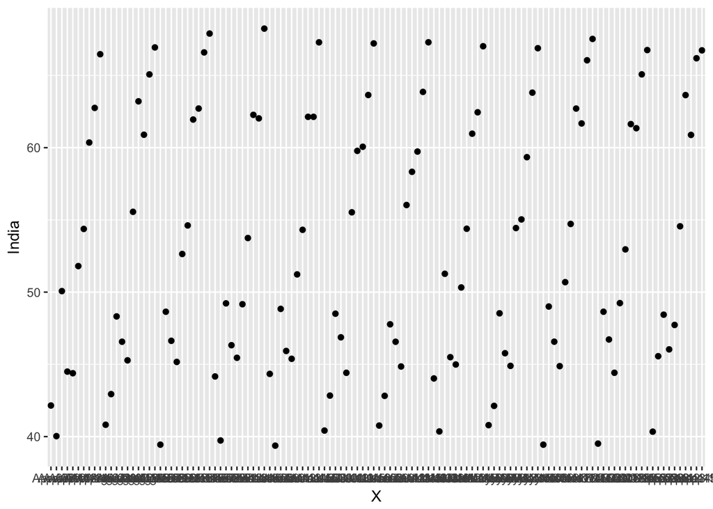

```r
a
```

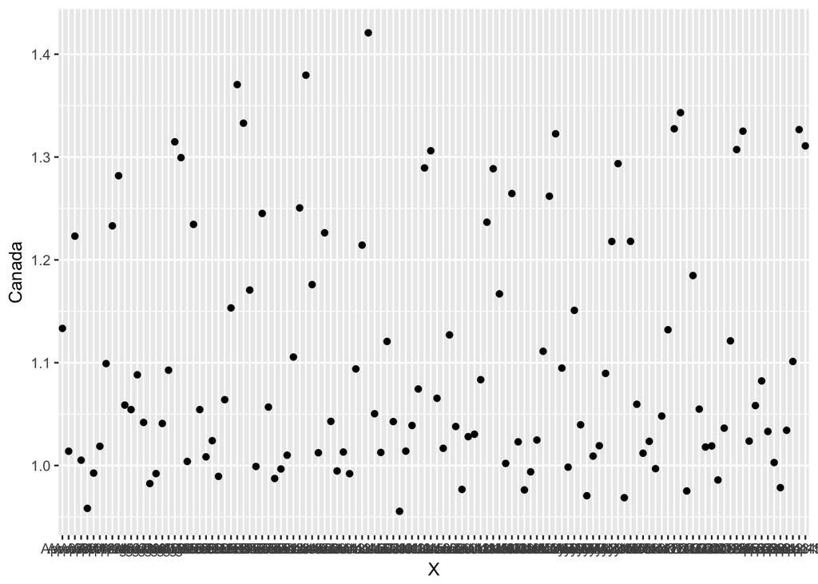

```r
b
```

The data needs to be further analyzed to find a trend, at this point in the analysis there are too many observations to find some sort of a trend or pattern if one exists.

I then took the total average exchange rates for each country and graphed them to understand and get a sense visually of how the exchange rates differed between countries (in USD):

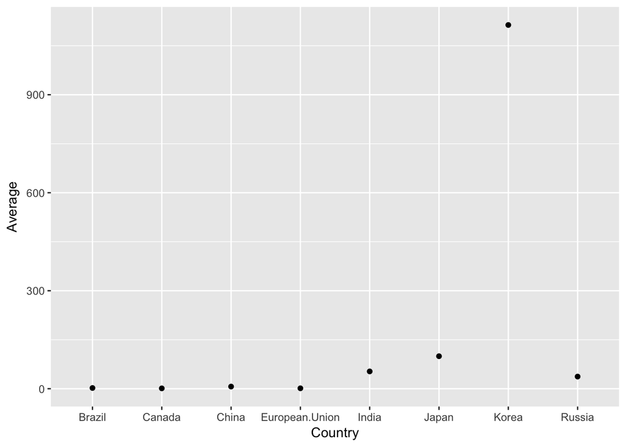

```r
c
```

### Univariate analysis by Category

In terms of analysis by Category, each of other datasets focuses on measuring one variable across time. The three categories I focused on thus were the unemployment rate across time and the Currency Rates across time for specifically India and Canada. In order to be able to generate better analysis, I further summarized the data by calculating averages for each of the data sets.

```r
#Unemployment data with averages added
head(dframe, n= 10)
```

```
##    Year Jan Feb Mar Apr May Jun Jul Aug Sep  Oct Nov Dec  Average
## 1  2007 4.6 4.5 4.4 4.5 4.4 4.6 4.7 4.6 4.7  4.7 4.7 5.0 4.616667
## 2  2008 5.0 4.9 5.1 5.0 5.4 5.6 5.8 6.1 6.1  6.5 6.8 7.3 5.800000
## 3  2009 7.8 8.3 8.7 9.0 9.4 9.5 9.5 9.6 9.8 10.0 9.9 9.9 9.283333
## 4  2010 9.8 9.8 9.9 9.9 9.6 9.4 9.4 9.5 9.5  9.4 9.8 9.3 9.608333
## 5  2011 9.1 9.0 9.0 9.1 9.0 9.1 9.0 9.0 9.0  8.8 8.6 8.5 8.933333
## 6  2012 8.3 8.3 8.2 8.2 8.2 8.2 8.2 8.1 7.8  7.8 7.7 7.9 8.075000
## 7  2013 8.0 7.7 7.5 7.6 7.5 7.5 7.3 7.3 7.2  7.2 6.9 6.7 7.366667
## 8  2014 6.6 6.7 6.7 6.2 6.3 6.1 6.2 6.2 5.9  5.7 5.8 5.6 6.166667
## 9  2015 5.7 5.5 5.4 5.4 5.5 5.3 5.2 5.1 5.0  5.0 5.0 5.0 5.258333
## 10 2016 4.9 4.9 5.0 5.0 4.7 4.9 4.9 4.9 4.9  4.8 4.6 4.7 4.850000
```

```r
#India's CurrencyRate Data
head(india_dframe, n= 10)
```

```
##    Year      Jan      Feb      Mar      Apr      May      Jun      Jul
## 1  2007 44.33947 44.16235 44.02550 42.15105 40.79200 40.76200 40.41636
## 2  2008 39.37273 39.72952 40.35667 40.03056 42.12550 42.82000 42.83652
## 3  2009 48.84000 49.22222 51.27000 50.07118 48.53400 47.77364 48.50773
## 4  2010 45.92684 46.32579 45.49800 44.49895 45.77053 46.56455 46.87211
## 5  2011 45.38421 45.45500 44.98955 44.38571 44.89500 44.85182 44.41528
## 6  2012 51.22737 49.16368 50.32300 51.80333 54.43619 56.03000 55.52650
## 7  2013 54.31320 53.74506 54.38784 54.37571 55.03335 58.32857 59.77943
## 8  2014 62.13515 62.27192 60.96696 60.35662 59.34279 59.73070 60.06376
## 9  2015 62.13536 62.02792 62.44984 62.75316 63.81019 63.86074 63.64583
## 10 2016 67.29337 68.24308 67.02185 66.46953 66.88611 67.29686 67.21679
##         Aug      Sep      Oct      Nov      Dec YearAverage
## 1  40.81762 40.34000 39.51318 39.44000 39.44000    41.34996
## 2  42.93895 45.56400 48.64222 49.00333 48.64190    43.50516
## 3  48.31895 48.43895 46.72105 46.56900 46.63000    48.40806
## 4  46.56650 46.03684 44.41750 44.87706 45.16895    45.71030
## 5  45.27850 47.72789 49.24000 50.69056 52.64053    46.66284
## 6  55.55952 54.55852 52.95839 54.71991 54.61627    53.41022
## 7  63.20884 63.64116 61.63115 62.70858 61.94803    58.59174
## 8  60.89517 60.88356 61.34802 61.67729 62.71092    61.03191
## 9  65.07233 66.19009 65.07548 66.05042 66.59551    64.13891
## 10 66.93964 66.73773 66.75722 67.52738 67.89891    67.19071
```

```r
head(can_dframe, n= 10)
```

```
##    Year       Jan       Feb       Mar      Apr      May      Jun       Jul
## 1  2007 1.1759318 1.1706600 1.1669150 1.133374 1.094710 1.065405 1.0503381
## 2  2008 1.0124045 0.9990857 1.0020250 1.013886 0.998395 1.016733 1.0126955
## 3  2009 1.2263000 1.2451400 1.2645136 1.223100 1.150920 1.127020 1.1206667
## 4  2010 1.0429350 1.0568200 1.0230043 1.005190 1.039589 1.037932 1.0427000
## 5  2011 0.9946833 0.9873800 0.9762429 0.958300 0.970600 0.976750 0.9554611
## 6  2012 1.0130750 0.9966421 0.9938545 0.992630 1.009162 1.028071 1.0139900
## 7  2013 0.9920762 1.0100333 1.0247889 1.018695 1.019238 1.030426 1.0389500
## 8  2014 1.0939400 1.1055105 1.1110842 1.099129 1.089570 1.083458 1.0743952
## 9  2015 1.2143421 1.2505444 1.2619136 1.233114 1.217858 1.236605 1.2894200
## 10 2016 1.4208211 1.3796100 1.3226182 1.281857 1.293615 1.288633 1.3061158
##          Aug       Sep       Oct       Nov       Dec YearAverage
## 1  1.0587682 1.0237278 0.9752318 0.9686800 1.0039529   1.0739745
## 2  1.0543950 1.0582952 1.1847500 1.2180222 1.2345000   1.0670990
## 3  1.0882100 1.0822300 1.0548524 1.0595750 1.0544000   1.1414106
## 4  1.0418950 1.0330857 1.0179750 1.0119444 1.0084333   1.0301253
## 5  0.9824476 1.0028750 1.0190278 1.0235053 1.0241421   0.9892846
## 6  0.9921409 0.9784556 0.9859350 0.9969471 0.9894312   0.9991946
## 7  1.0408619 1.0342400 1.0363500 1.0480778 1.0640222   1.0298133
## 8  1.0927250 1.1011810 1.1212238 1.1320176 1.1532524   1.1047905
## 9  1.3147842 1.3266952 1.3072667 1.3274833 1.3704667   1.2792078
## 10 1.2994364 1.3108667 1.3251450 1.3431421 1.3329350   1.3253996
```

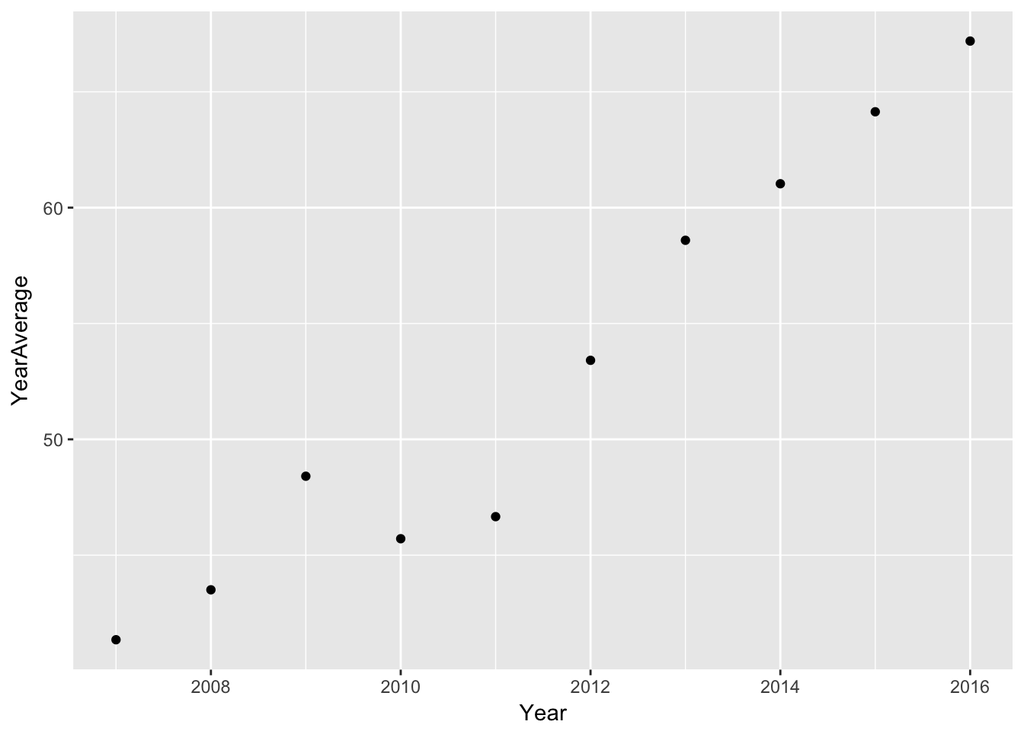

```r
#India
ind_avg
```

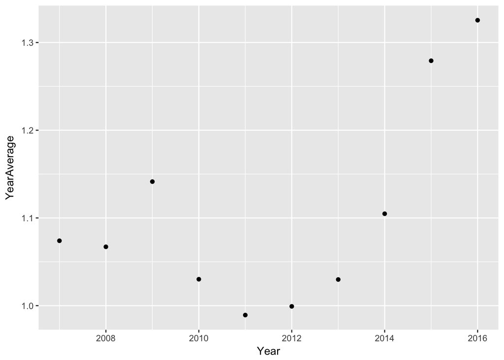

```r
#Canada
can_avg
```

The unemployment data average by year follows an interesting dramatic increase and fall trend:

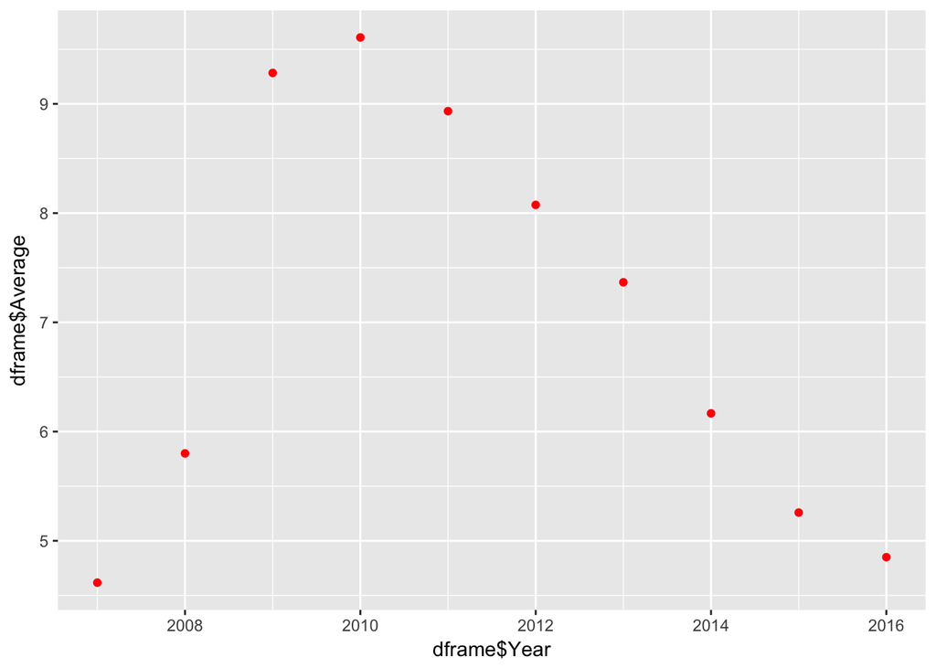

```r
unemp
```